# Hani_Eid_House_Prices

# Feature Engineering

# We here start the Feature Engineering.

## Filtering Methods

# We will rank the features according to their predictive power according to the methodologies seen in class: the Chi Squared Independence test and the Information Gain.

#### Full Model

# We first fit a lm model with all the features to have a baseline to evaluate the impact of the feature engineering.

```r
set.seed(121)
train_control_config <- trainControl(method = "repeatedcv",
                                     number = 5,
                                     repeats = 1,
                                     returnResamp = "all")

full.lm.mod <- train(SalePrice ~ ., data = training,
                     method = "lm",
                     metric = "RMSE",
                     preProc = c("center", "scale"),
                     trControl=train_control_config)
for (x in names(validation)) {
  full.lm.mod$xlevels[[x]] <- union(full.lm.mod$xlevels[[x]], levels(validation[[x]]))
}
SalePriceIndex = which(colnames(validation) == "SalePrice")
full.lm.mod.pred <- predict(full.lm.mod, validation[,-SalePriceIndex])
```

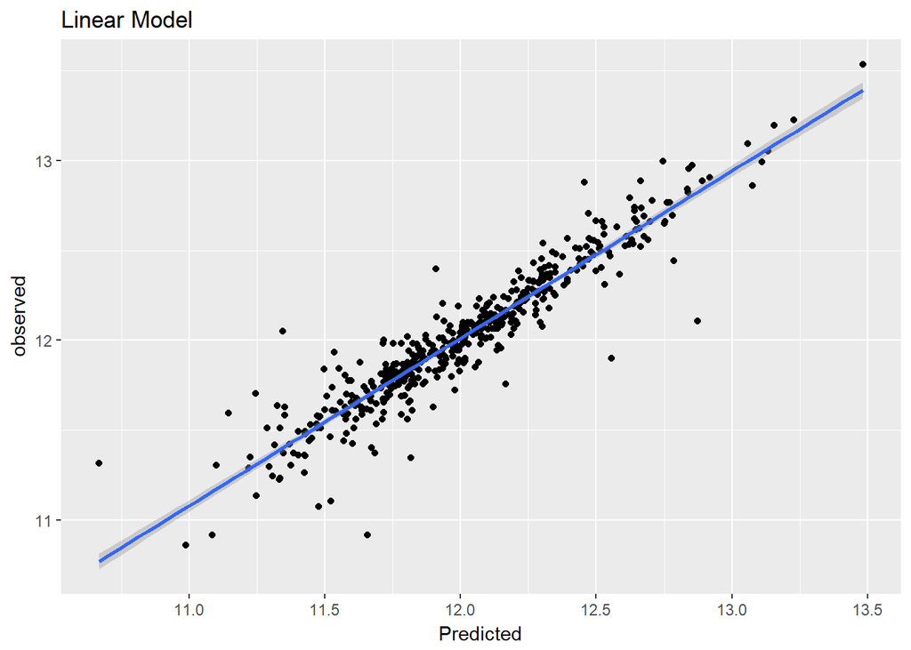

```r
full.lm.mod.pred[is.na(full.lm.mod.pred)] <- 0

my_data=as.data.frame(cbind(predicted=full.lm.mod.pred,observed=validation$SalePrice))

ggplot(my_data,aes(predicted,observed))+
  geom_point() + geom_smooth(method = "lm") +
  labs(x="Predicted") +
  ggtitle('Linear Model')
```

```r
paste("Full Linear Regression RMSE = ", sqrt(mean((full.lm.mod.pred - validation$SalePrice)^2)))
```

```
## [1] "Full Linear Regression RMSE =  0.136692889229455"
```

### Chi-squared Selection

# Making use of the `FSelector` package https://cran.r-project.org/web/packages/FSelector/FSelector.pdf, rank the features according to the Chi Squared value. If you’ve problems with this package (some of us have problems with it), do some research to find another packages that will provide the Chi squared selection.

# Does it make sense to remove some features? Is so, do it! **(Tip: Sure it does)**

```r
weights<- data.frame(chi.squared(SalePrice~., training_data))
weights$feature <- rownames(weights)
weights[order(weights$attr_importance, decreasing = TRUE),]
```

```
##               attr_importance       feature
## FullBath           0.64617395      FullBath
## TotalSF            0.53458491       TotalSF
## Fireplaces         0.51830168    Fireplaces
## OverallQual        0.51180529   OverallQual
## GarageCars         0.48588475    GarageCars
## Neighborhood       0.48004968  Neighborhood
## YearBuilt          0.43422304     YearBuilt
## KitchenQual        0.43152933   KitchenQual
## GrLivArea          0.43080554     GrLivArea
## ExterQual          0.42748396     ExterQual
## GarageFinish       0.39741281  GarageFinish
## BsmtQual           0.38464327      BsmtQual
## OpenPorchSF        0.37739714   OpenPorchSF
## TotalBsmtSF        0.37519464   TotalBsmtSF
## HalfBath           0.36491022      HalfBath
## MSSubClass         0.36397171    MSSubClass
## X1stFlrSF          0.35345237     X1stFlrSF
## CentralAir         0.34978950    CentralAir
## GarageType         0.32031064    GarageType
## X2ndFlrSF          0.31109688     X2ndFlrSF
## Foundation         0.30780250    Foundation
## FireplaceQu        0.30123366   FireplaceQu
## OverallCond        0.30116558   OverallCond
## BsmtFinSF1         0.29059544    BsmtFinSF1
## BedroomAbvGr       0.28244022  BedroomAbvGr
## LotFrontage        0.27991445   LotFrontage
## WoodDeckSF         0.27563964    WoodDeckSF
## BsmtFinType1       0.27518074  BsmtFinType1
## LotArea            0.27215568       LotArea
## Exterior1st        0.26795773   Exterior1st
## MasVnrArea         0.26771247    MasVnrArea
## Exterior2nd        0.26336535   Exterior2nd
## MasVnrType         0.25389263    MasVnrType
## HeatingQC          0.25207214     HeatingQC
## BsmtFullBath       0.24814910  BsmtFullBath
## EnclosedPorch      0.22947606 EnclosedPorch
## MSZoning           0.22939400      MSZoning
## PavedDrive         0.22259833    PavedDrive
## HouseStyle         0.21747814    HouseStyle
```

[output cut: 21 more lines]

```
## LotConfig          0.09255069     LotConfig
## Street             0.09130004        Street
## RoofMatl           0.08217501      RoofMatl
## Condition2         0.07518782    Condition2
## LandSlope          0.06891745     LandSlope
## MiscFeature        0.05788901   MiscFeature
## PoolQC             0.05690432        PoolQC
## BsmtFinSF2         0.00000000    BsmtFinSF2
## LowQualFinSF       0.00000000  LowQualFinSF
## BsmtHalfBath       0.00000000  BsmtHalfBath
## X3SsnPorch         0.00000000    X3SsnPorch
## PoolArea           0.00000000      PoolArea
## MiscVal            0.00000000       MiscVal
## MoSold             0.00000000        MoSold
## YrSold             0.00000000        YrSold
```

```r
chi_squared_features <- weights$feature[weights$attr_importance >= 0.1]
```

#### Evaluation

# Evaluate the impact (in terms of RMSE) of the feature selection.

# To that end, execute the previous LM model taking as input the filtered training set

```r
chi_squared.lm.mod <- train(SalePrice ~ ., data = training[append(chi_squared_features, "SalePrice")],
                            method = "lm",
                            metric = "RMSE",
                            preProc = c("center", "scale"),
                            trControl=train_control_config)
for (x in names(validation)) {
  chi_squared.lm.mod$xlevels[[x]] <- union(chi_squared.lm.mod$xlevels[[x]], levels(validation[[x]]))
}
chi_squared.lm.mod.pred <- predict(chi_squared.lm.mod, validation[,-SalePriceIndex])
```

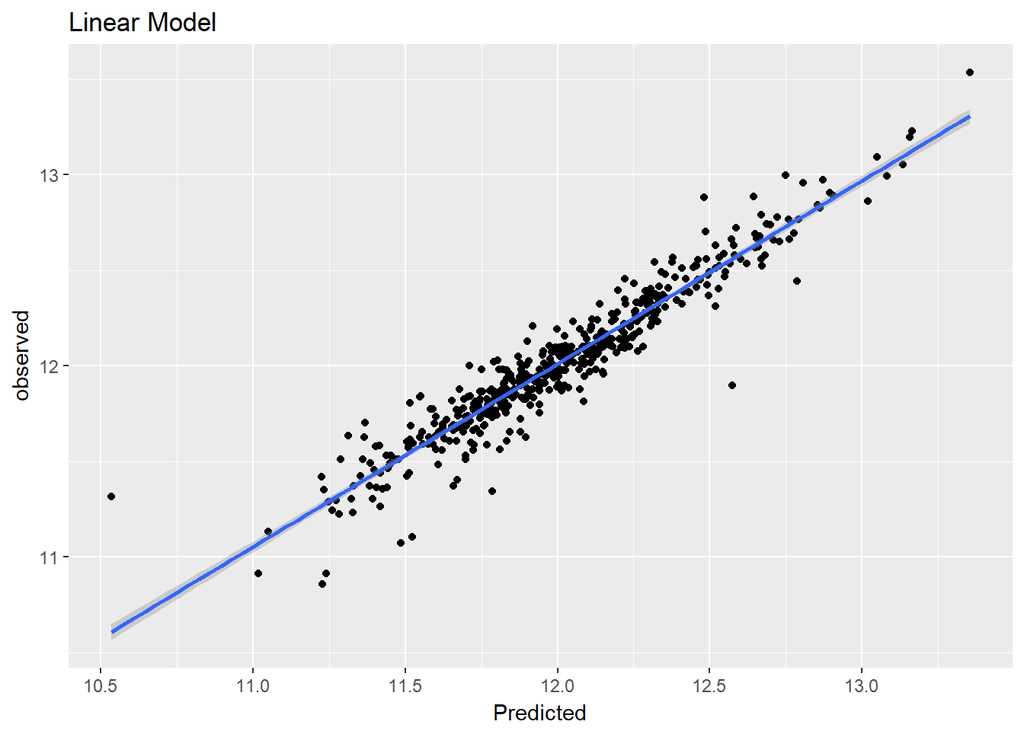

```r
chi_squared.lm.mod.pred[is.na(chi_squared.lm.mod.pred)] <- 0

my_data=as.data.frame(cbind(predicted=chi_squared.lm.mod.pred,observed=validation$SalePrice))

ggplot(my_data,aes(predicted,observed))+
  geom_point() + geom_smooth(method = "lm") +
  labs(x="Predicted") +
  ggtitle('Linear Model')
```

```r
paste("Chi-Squared Filtered Linear Regression RMSE = ", sqrt(mean((chi_squared.lm.mod.pred - validation$SalePrice)^2)))
```

```
## [1] "Chi-Squared Filtered Linear Regression RMSE =  0.119601175438951"
```

### Information Gain Selection

# Let’s experiment now with Information Gain Selection.

# Making also use of the `FSelector` package https://cran.r-project.org/web/packages/FSelector/FSelector.pdf, rank the features according to their Information Gain and filter those which you consider, according to the IG value.

# Again, there’re more alternatives to compute the IG.

```r
weights<- data.frame(information.gain(SalePrice~., training_data))
weights$feature <- rownames(weights)
weights[order(weights$attr_importance, decreasing = TRUE),]
```

```
##               attr_importance       feature
## TotalSF           0.549037000       TotalSF
## OverallQual       0.508310602   OverallQual
## Neighborhood      0.460940217  Neighborhood
## GrLivArea         0.385516275     GrLivArea
## GarageCars        0.326692321    GarageCars
## YearBuilt         0.299777831     YearBuilt
## BsmtQual          0.291492919      BsmtQual
## ExterQual         0.289411014     ExterQual
## KitchenQual       0.283816244   KitchenQual
## MSSubClass        0.281412749    MSSubClass
## TotalBsmtSF       0.279455891   TotalBsmtSF
## GarageFinish      0.250988376  GarageFinish
## X1stFlrSF         0.242552833     X1stFlrSF
## FullBath          0.236461507      FullBath
## GarageType        0.211967911    GarageType
## Foundation        0.197119032    Foundation
## FireplaceQu       0.192916015   FireplaceQu
## X2ndFlrSF         0.176502735     X2ndFlrSF
## BsmtFinType1      0.154278071  BsmtFinType1
## Fireplaces        0.148992504    Fireplaces
## OpenPorchSF       0.148429481   OpenPorchSF
## Exterior1st       0.145915429   Exterior1st
## Exterior2nd       0.143373264   Exterior2nd
## LotArea           0.141892620       LotArea
## LotFrontage       0.141696617   LotFrontage
## HeatingQC         0.134723773     HeatingQC
## BsmtFinSF1        0.116638914    BsmtFinSF1
## MSZoning          0.112537651      MSZoning
## MasVnrArea        0.105003852    MasVnrArea
## HouseStyle        0.099576942    HouseStyle
## MasVnrType        0.097980525    MasVnrType
## OverallCond       0.086613903   OverallCond
## WoodDeckSF        0.078723272    WoodDeckSF
## GarageQual        0.075999421    GarageQual
## GarageCond        0.072871860    GarageCond
## HalfBath          0.071542485      HalfBath
## BsmtUnfSF         0.069843738     BsmtUnfSF
## SaleCondition     0.064051289 SaleCondition
## SaleType          0.062301084      SaleType
```

[output cut: 21 more lines]

```
## ScreenPorch       0.015019907   ScreenPorch
## RoofMatl          0.012562105      RoofMatl
## Condition2        0.010439085    Condition2
## MiscFeature       0.007258580   MiscFeature
## LandSlope         0.004929373     LandSlope
## PoolQC            0.004773804        PoolQC
## Street            0.003849016        Street
## BsmtFinSF2        0.000000000    BsmtFinSF2
## LowQualFinSF      0.000000000  LowQualFinSF
## BsmtHalfBath      0.000000000  BsmtHalfBath
## X3SsnPorch        0.000000000    X3SsnPorch
## PoolArea          0.000000000      PoolArea
## MiscVal           0.000000000       MiscVal
## MoSold            0.000000000        MoSold
## YrSold            0.000000000        YrSold
```

```r
information_gain_features <- weights$feature[weights$attr_importance >= 0.05]
```

#### Evaluation

# Evaluate the impact of the IG selection in the model performance

```r
ig.lm.mod <- train(SalePrice ~ ., data = training[append(information_gain_features, "SalePrice")],
                   method = "lm",
                   metric = "RMSE",
                   preProc = c("center", "scale"),
                   trControl=train_control_config)
for (x in names(validation)) {
  ig.lm.mod$xlevels[[x]] <- union(ig.lm.mod$xlevels[[x]], levels(validation[[x]]))
}
ig.lm.mod.pred <- predict(ig.lm.mod, validation[,-SalePriceIndex])
```

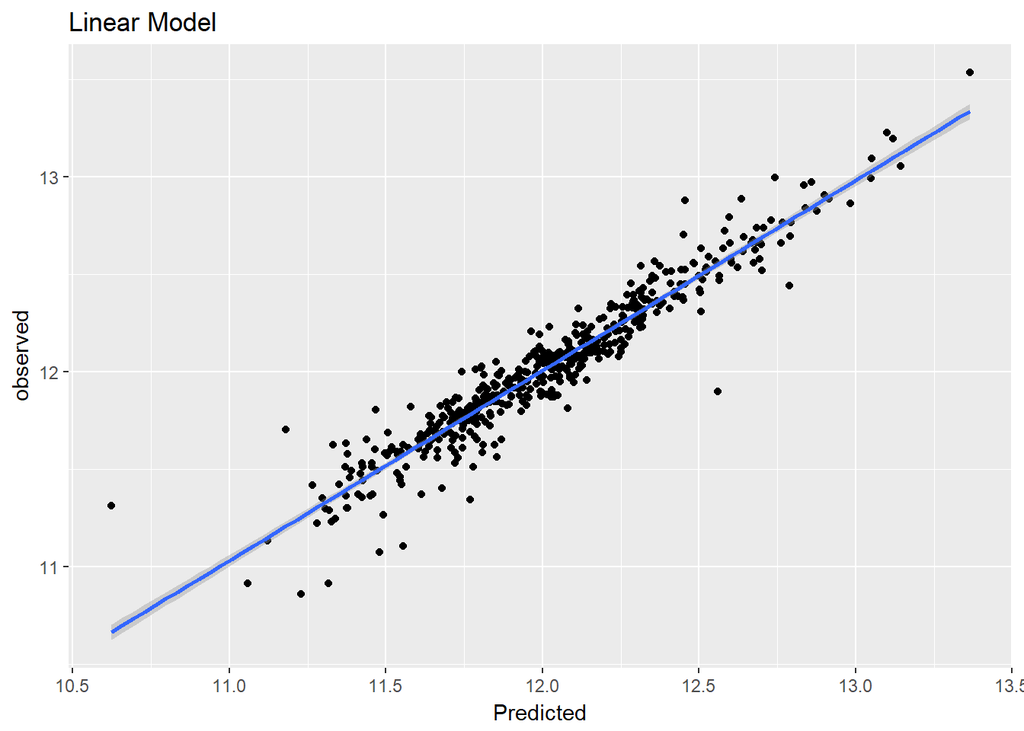

```r
ig.lm.mod.pred[is.na(ig.lm.mod.pred)] <- 0

my_data=as.data.frame(cbind(predicted=ig.lm.mod.pred,observed=validation$SalePrice))

ggplot(my_data,aes(predicted,observed))+
  geom_point() + geom_smooth(method = "lm") +
  labs(x="Predicted") +
  ggtitle('Linear Model')
```

```r
paste("IG Filtered Linear Regression RMSE = ", sqrt(mean((ig.lm.mod.pred - validation$SalePrice)^2)))
```

```
## [1] "IG Filtered Linear Regression RMSE =  0.117693669882619"
```